# A Break Down of Password Dumps and Data Breaches from 2004 to 2021

### Part 3: Data Breaches

It is important in this conversation to talk also about things outside of password security. It is one thing to have an extremely secure hashing system, but if there is nothing preventing it from being breached in the first place, then it cannot be said to truly be secure.

This next set is data breaches from 2004 to 2021. This is a set of data from Kaggle (https://www.kaggle.com/datasets/hishaamarmghan/list-of-top-data-breaches-2004-2021) that is simply an organization of the list of data breaches from the Wikipedia entry. There are hundreds if not thousands, if not, millions of data breaches every day and finding ones that are actually purposeful, relevant and large enough to be of any concern is important when considering the wider landscape. That’s why this data set works well for it, as they mostly concern public companies and large incidents.

The original data set is just a cleaning and reorganizing of information taken from Wikipedia. You can see we have five columns: Entity: which orginization was actually breached. Year: when did the event happen. Records: the number of PII records that were released Orginization.type: what general industry do they work in Method: what actually caused the data breach to occur.

Cleaning this was not easy in terms of data quality. There were too many organization types and methods to properly organize by either category. I went through them manually to try and weed out typos and capitalization issues and found further issues. There were many attempts to dual categorize that were removed, along with using two synonyms to describe the same thing and leading to two incidents that should be grouped together not being so. And since it was only about 250 rows of data, I just went through very briefly and fixed all of that by hand, pairing down the categories and methods to around 10 each.

```r
databeach <- read.csv("DataBreaches(2004-2021).csv") #the typo comforts my sanity bereft brain, so it gets to stay
databeach <- databeach[!(databeach$Organization.type == "hotel" | databeach$Organization.type == "online marketing" | databeach$Organization.type == "advertising" | databeach$Organization.type == "media" | databeach$Organization.type == "publisher (magazine)" | databeach$Organization.type == "transport" | databeach$Organization.type == "energy" | databeach$Organization.type == "mobile carrier" | databeach$Organization.type == "restaurant" ),]
glimpse(databeach)
```

```
## Rows: 277
## Columns: 5
## $ Entity            <chr> "21st Century Oncology", "500px", "Accendo Insurance…
## $ Year              <chr> "2016", "2020", "2020", "2013", "2019", "2017", "201…
## $ Records           <int> 2200000, 14870304, 175350, 152000000, 7500000, 40000…
## $ Organization.type <chr> "healthcare", "web", "healthcare", "tech", "tech", "…
## $ Method            <chr> "external threat actor", "external threat actor", "n…
```

what industries are being hacked most frequently? I grouped the incidents by their organization type and then year. Afterwards I summarized the records stolen for each year and then plotted that onto a line graph that I then faceted by industry.

```r
whoDF <- databeach %>% group_by(Organization.type, Year) %>% summarize(Recrods_Total = (sum(Records)))
```

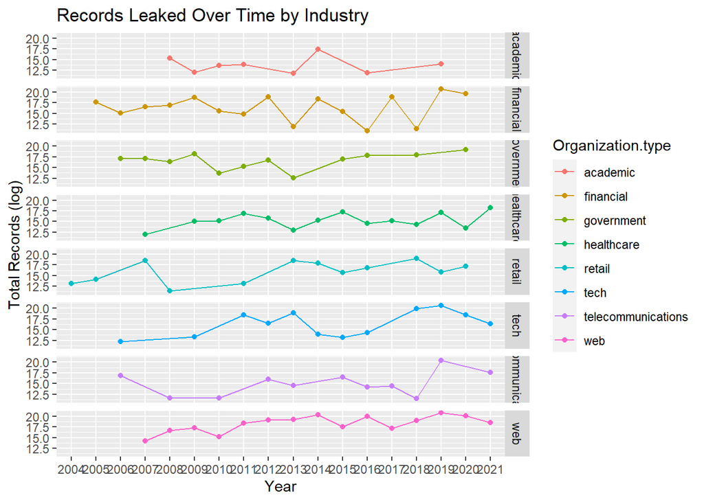

```r
options(repr.plot.width = 10, repr.plot.height =10)
whoDF %>% ggplot(aes(x = Year, y = log(Recrods_Total), color = Organization.type)) + geom_point()+geom_line(group = 1)+ facet_grid(rows = vars(Organization.type), space = "free_y") + ggtitle("Records Leaked Over Time by Industry ") + ylab("Total Records (log)")
```

What is causing the hacks? In order to find this, the code I used was almost identical to the previous block except for two things. First, it was grouped by method rather than orginization type and Second, it was placed in a tree map instead of a line graph. This works better for this as it shows the weight of each breach type.

```r
whyDF <- databeach %>% group_by(Organization.type, Method) %>%  summarize (total_rec = sum(Records)) #%>% summarize ("Total Incidents" = nrow(Records))
```

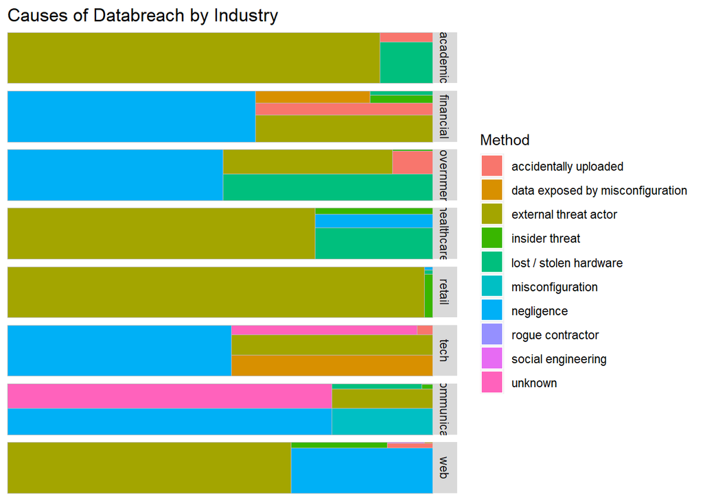

```r
whyDF %>% ggplot(aes(area = total_rec, fill = Method)) + geom_treemap() + facet_grid(row = vars(Organization.type)) + ggtitle("Causes of Databreach by Industry")
```

First most common method is “External threat actor”, which is generally what you think of when you hear about hacking. Outside actors force their way into a network via some sort of exploit or unknown backdoor. Second is negligence, which is like saying “the reason the house was robbed was because they never added a lock”. Organizations sometimes do not perform the most basic procedures as required for their industry and it leads to people basically walking into their network and stealing data.

Another notable “unknown”. There is a AT&T breach that occurred in 2019 that still has an unknown cause. This makes up the large pink bar for telecommunications.

### Conclusion

At the end of the day, nothing can be truly be done to ensure total security. There will always be some slip up, some mistake, some inside threat that leads to a seemingly perfect company having their network breached and their user data put into the hands of malicious actors. The best way to prevent that is to make sure you are varying your passwords between sites so even if one is stolen, the rest don’t fall with it.